# Buổi 3_Phân tích và hiển thị dữ liệu

```python
v = list(range(1,6))
print(v)
print(2*v)
```

```
[1, 2, 3, 4, 5]
[1, 2, 3, 4, 5, 1, 2, 3, 4, 5]
```

```python
import numpy as np
v = np.arange(1,6)
print(v)
print(v*2)
```

```
[1 2 3 4 5]
[ 2  4  6  8 10]
```

**Mục đích:** Tạo một mảng `numpy` gồm các số từ 1 đến 5, sau đó in ra mảng gốc và mảng đã nhân đôi giá trị của từng phần tử.

```python
fruits = ["apple", "banana", "cherry"] #lists []
colors = ("red", "green", "blue") #tuples ()
animals = {'cat', 'dog'} #sets {}
person = {"name" : "Tom", "age" : 20} #dictionaries {}
```

**Mục đích:** Khởi tạo bốn kiểu dữ liệu khác nhau trong Python — list, tuple, set và dictionary — để minh họa cách lưu trữ và truy cập dữ liệu theo các cấu trúc khác nhau.

```python
x = [60, 70, 80, 90]
print('len(x)=',len(x))
print('x[0]=',x[0])
print('x[1]=', x[1])
print('x[-1]=',x[-1])
print('x[1:3]=',x[1:3])
```

```
len(x)= 4
x[0]= 60
x[1]= 70
x[-1]= 90
x[1:3]= [70, 80]
```

**Mục đích:** Minh họa cách truy cập phần tử trong list `x` bằng chỉ số, bao gồm độ dài list, phần tử đầu tiên, phần tử thứ hai, phần tử cuối cùng và lát cắt con list từ vị trí 1 đến 2.

## Thực hành với thu viện Numpy

```python
from IPython.display import display
import numpy as np
a = np.array([1, 2, 3])
b = np.array([4, 5, 6])
c = a * b
print('c = ')
display(c)
```

```
c =
```

```
array([ 4, 10, 18])
```

**Mục đích:** Thực hiện phép nhân từng phần tử giữa hai mảng `numpy` `a` và `b`, sau đó in và hiển thị kết quả mảng `c` bằng hàm `display()`.

```python
import numpy as np

a = np.zeros((2,2))
display(a)

b = np.ones((3,2))
display(b)

c = np.full((4,5),7)
display(c)

d = np.eye(4)
display(d)

e = np.random.random((2,2))
display(e)
```

```
array([[0., 0.],
       [0., 0.]])
```

```
array([[1., 1.],
       [1., 1.],
       [1., 1.]])
```

```
array([[7, 7, 7, 7, 7],
       [7, 7, 7, 7, 7],
       [7, 7, 7, 7, 7],
       [7, 7, 7, 7, 7]])
```

```
array([[1., 0., 0., 0.],
       [0., 1., 0., 0.],
       [0., 0., 1., 0.],
       [0., 0., 0., 1.]])
```

```
array([[0.88634931, 0.46788359],
       [0.83353314, 0.59742238]])
```

```python
import numpy as np
a = np.arange(15, dtype=float)
display(a)

a = a.reshape(3,5)
display(a)

display(a.shape)
display(a.ndim)
display(a.dtype)
```

```
array([ 0.,  1.,  2.,  3.,  4.,  5.,  6.,  7.,  8.,  9., 10., 11., 12.,
       13., 14.])
```

```
array([[ 0.,  1.,  2.,  3.,  4.],
       [ 5.,  6.,  7.,  8.,  9.],
       [10., 11., 12., 13., 14.]])
```

```
(3, 5)
```

```
2
```

```
dtype('float64')
```

**Mục đích:** Khởi tạo mảng `numpy` gồm 15 giá trị float liên tiếp, định hình lại thành ma trận 3 hàng 5 cột, và hiển thị các thuộc tính cơ bản của mảng gồm kích thước (`shape`), số chiều (`ndim`), cùng kiểu dữ liệu (`dtype`).

```python
import numpy as np
a = np.array([1,2,3,4,5])
display(a)
```

```
array([1, 2, 3, 4, 5])
```

```python
a = np.array([
    [1,2,3,4,5],
    [6,7,8,9,10],
    [11,12,13,14,15],
    [16,17,18,19,20]
])
display(a)
display(a.shape)
display(a.ndim)
display(a.dtype)
```

```
array([[ 1,  2,  3,  4,  5],
       [ 6,  7,  8,  9, 10],
       [11, 12, 13, 14, 15],
       [16, 17, 18, 19, 20]])
```

```
(4, 5)
```

```
2
```

```
dtype('int64')
```

```python
a = np.array([
    [0,1,2,3],
    [10,11,12,13],
    [20,21,22,23]
])
display(a)
display(a.shape)
display(a.ndim)
```

```
array([[ 0,  1,  2,  3],
       [10, 11, 12, 13],
       [20, 21, 22, 23]])
```

```
(3, 4)
```

```
2
```

**Mục đích:** Tạo một mảng hai chiều `numpy` gồm 3 hàng và 4 cột, sau đó hiển thị nội dung mảng cùng với các thuộc tính cơ bản là kích thước (`shape`) và số chiều (`ndim`).

```python
a = np.arange(1, 10).reshape(3,3)
display(a)
```

```
array([[1, 2, 3],
       [4, 5, 6],
       [7, 8, 9]])
```

**Mục đích:** Tạo một mảng `numpy` gồm các số từ 1 đến 9 và định hình lại thành ma trận vuông 3x3, sau đó hiển thị kết quả.

```python
display(a[2])
display(a[2].shape)

display(a[2,:])
display(a[2,:].shape)

display(a[2:,:])
display(a[2:,:].shape)
```

```
array([7, 8, 9])
```

```
(3,)
```

```
array([7, 8, 9])
```

```
(3,)
```

```
array([[7, 8, 9]])
```

```
(1, 3)
```

**Mục đích:** Minh họa cách truy cập và cắt lát hàng trong mảng `numpy` 2 chiều. Cụ thể: lấy toàn bộ hàng thứ 3 (`a[2]`), hàng thứ 3 theo cú pháp đầy đủ (`a[2, :]`), và tất cả các hàng từ hàng thứ 3 trở đi (`a[2:,]`), đồng thời hiển thị hình dạng (`shape`) tương ứng của từng kết quả.

## Thực hành với thư viện Pandas

```python
from IPython.display import display
import pandas as pd
a = pd.DataFrame({
        'a': [4,5,6],
        'b': [7,8,9],
        'c': [10,11,12],
    }, index = [1,2,3])
display(a)
display(a.loc[1])

b = pd.DataFrame([
    {'a':4,'b':7,'c':10},
    {'a':5,'b':8,'c':11},
    {'a':6,'b':9,'c':12},
])
display(b)
display(b.loc[1])
```

|  | a | b | c |
| --- | --- | --- | --- |
| 1 | 4 | 7 | 10 |
| 2 | 5 | 8 | 11 |
| 3 | 6 | 9 | 12 |

```
a     4
b     7
c    10
Name: 1, dtype: int64
```

|  | a | b | c |
| --- | --- | --- | --- |
| 0 | 4 | 7 | 10 |
| 1 | 5 | 8 | 11 |
| 2 | 6 | 9 | 12 |

```
a     5
b     8
c    11
Name: 1, dtype: int64
```

**Mục đích:** Minh họa cách tạo và truy cập dữ liệu trong `pandas.DataFrame` bằng hai phương pháp khác nhau.

- Ở phần đầu, DataFrame `a` được tạo từ một dictionary, trong đó mỗi khóa đại diện cho một cột và `index` được gán thủ công là `[1,2,3]`. Sau đó, sử dụng `a.loc[1]` để truy xuất toàn bộ hàng có chỉ số 1.
- Ở phần sau, DataFrame `b` được khởi tạo từ danh sách các dictionary, mỗi dictionary tương ứng với một hàng dữ liệu. Tiếp tục dùng `b.loc[1]` để truy cập hàng thứ hai trong bảng (vì chỉ số mặc định bắt đầu từ 0).  
  Cả hai cách đều cho kết quả tương tự nhưng thể hiện hai phương thức khởi tạo DataFrame phổ biến trong `pandas`.

```python
display(type(a))
```

```
pandas.core.frame.DataFrame
```

```python
import numpy as np
import pandas as pd
import matplotlib.pyplot as plt

s = pd.Series([1,3,5,np.nan,6,8])
display(s)

dates = pd.date_range('20181001', periods = 6)
display(dates)
```

```
0    1.0
1    3.0
2    5.0
3    NaN
4    6.0
5    8.0
dtype: float64
```

```
DatetimeIndex(['2018-10-01', '2018-10-02', '2018-10-03', '2018-10-04',
               '2018-10-05', '2018-10-06'],
              dtype='datetime64[ns]', freq='D')
```

**Mục đích:** Giới thiệu hai cấu trúc dữ liệu cơ bản trong `pandas`: `Series` và `DatetimeIndex`.

- Đầu tiên, tạo một đối tượng `Series` chứa các giá trị số, trong đó có một giá trị bị thiếu (`NaN`), minh họa khả năng xử lý dữ liệu thiếu của `pandas`.
- Tiếp theo, tạo một dãy ngày (`DatetimeIndex`) gồm 6 ngày liên tiếp bắt đầu từ ngày 01/10/2018 bằng hàm `pd.date_range()`, thường dùng để gán làm chỉ mục thời gian cho dữ liệu chuỗi thời gian.

```python
df = pd.DataFrame(np.random.randn(6,4), columns=['A','B','C','D'], index = dates)
display(df)

display(df.loc['2018-10-03'])
display(df['B'])
```

|  | A | B | C | D |
| --- | --- | --- | --- | --- |
| 2018-10-01 | -0.812298 | 0.243527 | -0.169826 | -0.152339 |
| 2018-10-02 | 0.452627 | -0.890433 | -0.238698 | -0.269286 |
| 2018-10-03 | -1.136511 | 0.643202 | 1.077230 | -0.291040 |
| 2018-10-04 | 0.751174 | 0.581389 | -1.354584 | 0.370192 |
| 2018-10-05 | 0.418577 | -1.462258 | 0.395155 | -0.346258 |
| 2018-10-06 | 0.357212 | -0.929648 | -0.565685 | -0.484340 |

```
A   -1.136511
B    0.643202
C    1.077230
D   -0.291040
Name: 2018-10-03 00:00:00, dtype: float64
```

```
2018-10-01    0.243527
2018-10-02   -0.890433
2018-10-03    0.643202
2018-10-04    0.581389
2018-10-05   -1.462258
2018-10-06   -0.929648
Freq: D, Name: B, dtype: float64
```

**Mục đích:** Tạo một `DataFrame` gồm 6 hàng và 4 cột (`A`, `B`, `C`, `D`) chứa các giá trị ngẫu nhiên, với chỉ mục là chuỗi ngày `dates` đã tạo trước đó.  
Sau đó:

- `df.loc['2018-10-03']` được dùng để truy xuất toàn bộ dữ liệu của hàng có ngày 03/10/2018.
- `df['B']` lấy toàn bộ cột `B` trong DataFrame, minh họa cách truy cập dữ liệu theo hàng và cột trong `pandas`.

```python
df = pd.DataFrame(np.random.randn(3,5), columns=list('ABCDE'), index=['student 1','student 2', 'student 3'])
df
```

|  | A | B | C | D | E |
| --- | --- | --- | --- | --- | --- |
| student 1 | -0.573560 | 0.377123 | 0.779121 | 1.162055 | 0.836426 |
| student 2 | -0.068122 | -0.163365 | -1.321871 | -0.952830 | -1.981419 |
| student 3 | -0.160044 | -0.636837 | 1.292314 | 1.085127 | 0.476849 |

**Mục đích:** Tạo một `DataFrame` trong `pandas` gồm 3 hàng và 5 cột (`A` đến `E`), chứa các giá trị ngẫu nhiên.  
Chỉ mục của các hàng được đặt tên là `'student 1'`, `'student 2'`, và `'student 3'`, giúp minh họa cách gán nhãn tùy chỉnh cho các hàng trong DataFrame.

```python
df2 = pd.DataFrame({
    'A' : 1.,
    'B' : pd.Timestamp('20181001'),
    'C' : pd.Series(2.5,index=list(range(4)),dtype='float32'),
    'D' : np.array([3] * 4,dtype='int32'),
    'E' : pd.Categorical(["test","train","test","train"]),
    'F' : 'foo'
})
display(df2)
```

|  | A | B | C | D | E | F |
| --- | --- | --- | --- | --- | --- | --- |
| 0 | 1.0 | 2018-10-01 | 2.5 | 3 | test | foo |
| 1 | 1.0 | 2018-10-01 | 2.5 | 3 | train | foo |
| 2 | 1.0 | 2018-10-01 | 2.5 | 3 | test | foo |
| 3 | 1.0 | 2018-10-01 | 2.5 | 3 | train | foo |

**Mục đích:** Tạo một `DataFrame` phức hợp trong `pandas` để minh họa khả năng xử lý nhiều kiểu dữ liệu khác nhau trong cùng một bảng.  
Cụ thể:

- Cột `A` là giá trị số thực cố định.
- Cột `B` chứa dữ liệu thời gian (`Timestamp`).
- Cột `C` là `Series` kiểu `float32`.
- Cột `D` là mảng `numpy` kiểu `int32`.
- Cột `E` là dữ liệu phân loại (`Categorical`).
- Cột `F` chứa chuỗi ký tự giống nhau.  
  Đoạn code cho thấy cách `pandas` tự động quản lý và tối ưu hóa các kiểu dữ liệu khác nhau trong cùng một `DataFrame`.

```python
df2.dtypes
```

```
A          float64
B    datetime64[s]
C          float32
D            int32
E         category
F           object
dtype: object
```

```python
import pandas as pd
from IPython.display import display

# Create a DataFrame to store transactions
columns = ['Date', 'Description', 'Amount']
ledger = pd.DataFrame(columns=columns)
# display(ledger)

# Init a DataFrame to store transactions
def init_ledger():
    return pd.DataFrame(columns=columns)

# Function to add a transaction
def add_transaction(date, description, amount):
    global ledger
    new_transaction = pd.DataFrame([[date, description, amount]], columns=columns)
    ledger = pd.concat([ledger, new_transaction], ignore_index=True)

# Function to view the ledger
def view_ledger():
    display(ledger)

# Function to get the current balance
def get_balance():
    return ledger['Amount'].sum()

ledger = init_ledger()

# Adding sample transactions
add_transaction('2023-11-01', 'Income', 1000)
add_transaction('2023-11-02', 'Groceries', -200)
add_transaction('2023-11-03', 'Utilities', -100)

# Viewing the ledger
view_ledger()

# Checking the current balance
print("Current Balance:", get_balance())
```

|  | Date | Description | Amount |
| --- | --- | --- | --- |
| 0 | 2023-11-01 | Income | 1000 |
| 1 | 2023-11-02 | Groceries | -200 |
| 2 | 2023-11-03 | Utilities | -100 |

```
Current Balance: 700
```

## Bìa tập Iris Classifier

```python
import urllib.request

url = "https://archive.ics.uci.edu/ml/machine-learning-databases/iris/iris.data"
urllib.request.urlretrieve(url, "iris.data")
```

```
('iris.data', <http.client.HTTPMessage at 0x16e7339f6f0>)
```

```python
with open("iris.data", "r") as f:
    print(f.read()[:500])  # in 500 ký tự đầu tiên để xem thử nội dung
```

```
5.1,3.5,1.4,0.2,Iris-setosa
4.9,3.0,1.4,0.2,Iris-setosa
4.7,3.2,1.3,0.2,Iris-setosa
4.6,3.1,1.5,0.2,Iris-setosa
5.0,3.6,1.4,0.2,Iris-setosa
5.4,3.9,1.7,0.4,Iris-setosa
4.6,3.4,1.4,0.3,Iris-setosa
5.0,3.4,1.5,0.2,Iris-setosa
4.4,2.9,1.4,0.2,Iris-setosa
4.9,3.1,1.5,0.1,Iris-setosa
5.4,3.7,1.5,0.2,Iris-setosa
4.8,3.4,1.6,0.2,Iris-setosa
4.8,3.0,1.4,0.1,Iris-setosa
4.3,3.0,1.1,0.1,Iris-setosa
5.8,4.0,1.2,0.2,Iris-setosa
5.7,4.4,1.5,0.4,Iris-setosa
5.4,3.9,1.3,0.4,Iris-setosa
5.1,3.5,1.4,0.3,Iris-set
```

```python
# Load dataset
url = "https://archive.ics.uci.edu/ml/machine-learning-databases/iris/iris.data"
names = ['sepal-length', 'sepal-width', 'petal-length', 'petal-width', 'class']
df = pd.read_csv(url, names=names)
print(df.head(10))
```

```
   sepal-length  sepal-width  petal-length  petal-width        class
0           5.1          3.5           1.4          0.2  Iris-setosa
1           4.9          3.0           1.4          0.2  Iris-setosa
2           4.7          3.2           1.3          0.2  Iris-setosa
3           4.6          3.1           1.5          0.2  Iris-setosa
4           5.0          3.6           1.4          0.2  Iris-setosa
5           5.4          3.9           1.7          0.4  Iris-setosa
6           4.6          3.4           1.4          0.3  Iris-setosa
7           5.0          3.4           1.5          0.2  Iris-setosa
8           4.4          2.9           1.4          0.2  Iris-setosa
9           4.9          3.1           1.5          0.1  Iris-setosa
```

**Mục đích:** Tải bộ dữ liệu *Iris* trực tiếp từ kho dữ liệu của UCI Machine Learning Repository và đọc vào `DataFrame` bằng `pandas`.  
Các bước thực hiện:

- Gán đường dẫn dữ liệu `iris.data` vào biến `url`.
- Đặt tên cho các cột gồm: `sepal-length`, `sepal-width`, `petal-length`, `petal-width`, và `class`.
- Dùng `pd.read_csv()` để đọc dữ liệu và gán tên cột tương ứng.
- Cuối cùng, in ra 10 dòng đầu tiên bằng `df.head(10)` để xem cấu trúc dữ liệu.

```python
df.tail(10)
```

|  | sepal-length | sepal-width | petal-length | petal-width | class |
| --- | --- | --- | --- | --- | --- |
| 140 | 6.7 | 3.1 | 5.6 | 2.4 | Iris-virginica |
| 141 | 6.9 | 3.1 | 5.1 | 2.3 | Iris-virginica |
| 142 | 5.8 | 2.7 | 5.1 | 1.9 | Iris-virginica |
| 143 | 6.8 | 3.2 | 5.9 | 2.3 | Iris-virginica |
| 144 | 6.7 | 3.3 | 5.7 | 2.5 | Iris-virginica |
| 145 | 6.7 | 3.0 | 5.2 | 2.3 | Iris-virginica |
| 146 | 6.3 | 2.5 | 5.0 | 1.9 | Iris-virginica |
| 147 | 6.5 | 3.0 | 5.2 | 2.0 | Iris-virginica |
| 148 | 6.2 | 3.4 | 5.4 | 2.3 | Iris-virginica |
| 149 | 5.9 | 3.0 | 5.1 | 1.8 | Iris-virginica |

```python
df.describe() # Mô tả các thông số thống kê
```

|  | sepal-length | sepal-width | petal-length | petal-width |
| --- | --- | --- | --- | --- |
| count | 150.000000 | 150.000000 | 150.000000 | 150.000000 |
| mean | 5.843333 | 3.054000 | 3.758667 | 1.198667 |
| std | 0.828066 | 0.433594 | 1.764420 | 0.763161 |
| min | 4.300000 | 2.000000 | 1.000000 | 0.100000 |
| 25% | 5.100000 | 2.800000 | 1.600000 | 0.300000 |
| 50% | 5.800000 | 3.000000 | 4.350000 | 1.300000 |
| 75% | 6.400000 | 3.300000 | 5.100000 | 1.800000 |
| max | 7.900000 | 4.400000 | 6.900000 | 2.500000 |

```python
df.info() # thông tin của bộ dữ liệu
```

```
<class 'pandas.core.frame.DataFrame'>
RangeIndex: 150 entries, 0 to 149
Data columns (total 5 columns):
 #   Column        Non-Null Count  Dtype
---  ------        --------------  -----
 0   sepal-length  150 non-null    float64
 1   sepal-width   150 non-null    float64
 2   petal-length  150 non-null    float64
 3   petal-width   150 non-null    float64
 4   class         150 non-null    object
dtypes: float64(4), object(1)
memory usage: 6.0+ KB
```

```python
df.shape
```

```
(150, 5)
```

```python
df.groupby('class').size()
```

```
class
Iris-setosa        50
Iris-versicolor    50
Iris-virginica     50
dtype: int64
```

```python
np.unique(df['class'], return_counts=True)
```

```
(array(['Iris-setosa', 'Iris-versicolor', 'Iris-virginica'], dtype=object),
 array([50, 50, 50]))
```

**Mục đích:** Đếm số lượng mẫu thuộc từng lớp trong cột `class` của bộ dữ liệu *Iris*.  
Cụ thể, hàm `np.unique(..., return_counts=True)` trả về hai mảng:

- Mảng thứ nhất là các giá trị duy nhất trong cột `class` (tên các loài hoa).
- Mảng thứ hai là số lượng mẫu tương ứng của từng loài.  
  Điều này giúp kiểm tra sự phân bố dữ liệu giữa các lớp trong tập dữ liệu.

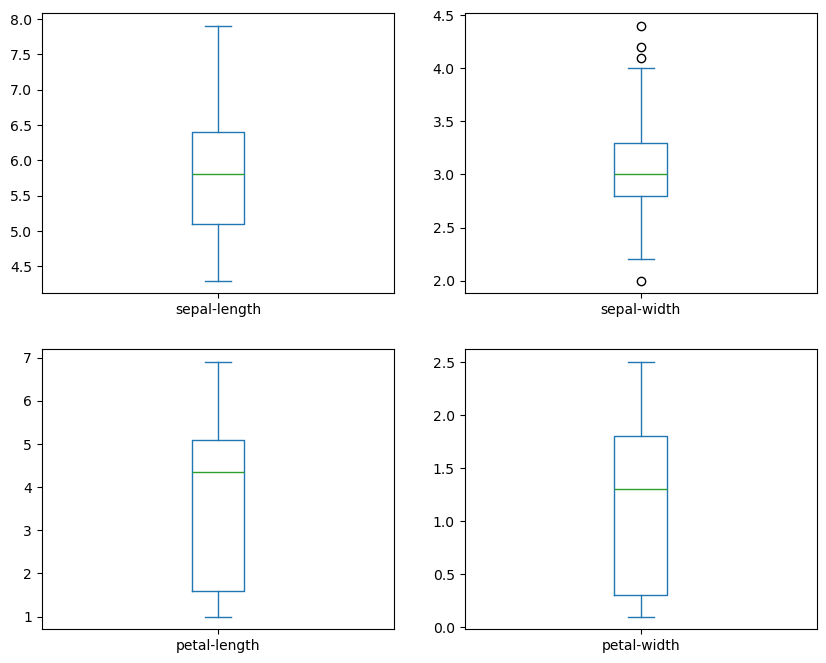

```python
plt.rcParams["figure.figsize"] = (10,8)
df.plot(kind='box', subplots=True, layout=(2,2), sharex=False, sharey=False)
plt.show()
```

**Mục đích:** Trực quan hóa dữ liệu *Iris* bằng biểu đồ hộp (boxplot) để quan sát phân bố và phát hiện giá trị ngoại lai (outliers) trong từng biến định lượng.  
Cụ thể:

- `plt.rcParams["figure.figsize"] = (10,8)` đặt kích thước toàn cục của biểu đồ là 10x8 inch.
- `df.plot(kind='box', subplots=True, layout=(2,2), sharex=False, sharey=False)` vẽ các boxplot riêng biệt cho từng cột, sắp xếp theo lưới 2x2 và không chia sẻ trục.
- `plt.show()` hiển thị toàn bộ biểu đồ.

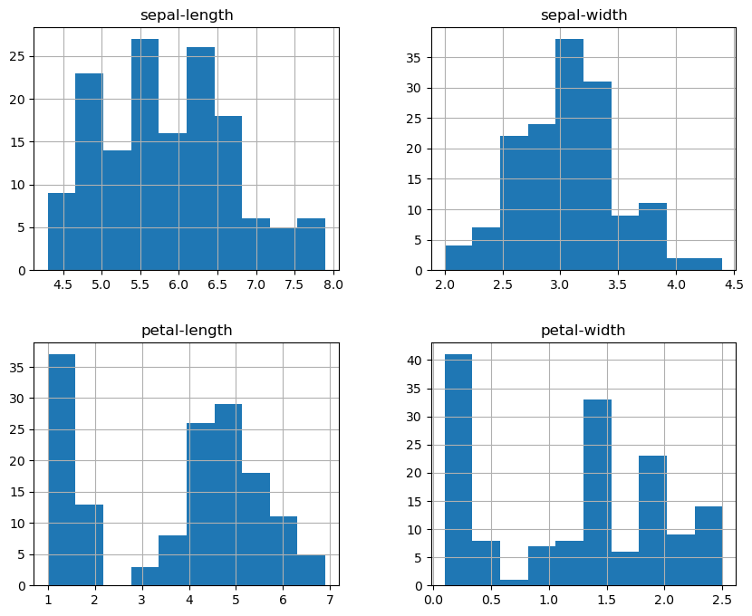

```python
df.hist()
plt.show()
```

**Mục đích:** Vẽ biểu đồ tần suất (histogram) cho từng biến số trong bộ dữ liệu *Iris* để quan sát phân bố giá trị của chúng.  
Cụ thể:

- `df.hist()` tự động tạo các biểu đồ histogram cho tất cả các cột số trong `DataFrame`.
- `plt.show()` hiển thị toàn bộ các biểu đồ này, giúp nhận diện xu hướng, độ lệch và phân phối của dữ liệu.

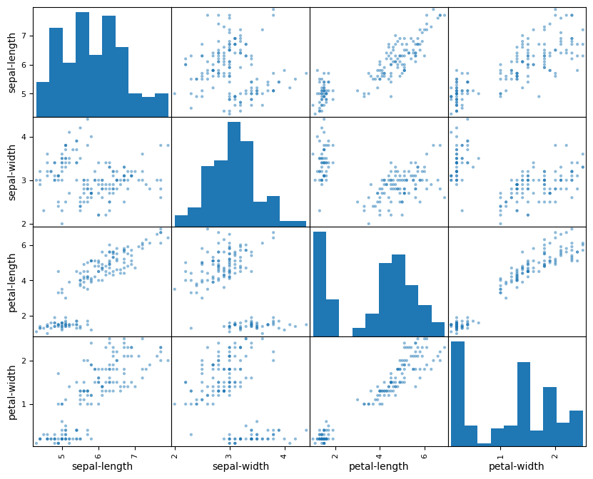

```python
from pandas.plotting import scatter_matrix
scatter_matrix(df)
plt.show()
```

**Mục đích:** Tạo ma trận biểu đồ phân tán (scatter matrix) cho bộ dữ liệu *Iris* nhằm quan sát mối quan hệ giữa các cặp biến định lượng.  
Cụ thể:

- `scatter_matrix(df)` vẽ tập hợp các biểu đồ phân tán giữa mọi cặp cột số trong `DataFrame`, đồng thời hiển thị histogram trên đường chéo chính.
- `plt.show()` dùng để hiển thị toàn bộ ma trận biểu đồ, giúp nhận diện tương quan và xu hướng tuyến tính giữa các đặc trưng của hoa.

## Kết thúc buổi 3